# Individual Project: Demand Forecasting for A Fast-Food Restaurant Chain

Qian Zhang

2021年3月15日

### Section 1: Data Processing:

I used Python to calculate the daily demand of lettuce for each store. The python code is attacted in the appendix. The demand for store 4904, 12631, 20974, and 46673 are stored in lettuce_demand_4904.csv, lettuce_demand_12631.csv, lettuce_demand_20974.csv, lettuce_demand_46673.csv, respectively. The calculated daily demand of lettuce of store 46673 are compared to the first few observations provided by professor and they are identical.

### Section 2: Forcasting The Demand of Store 4904

The first step is to import the data, and divide the dataset into training dataset and testing dataset appropriately. In general, if the training dataset is too large and the testing dataset is too small, we will have less data to test the performance of the model and the variance will be larger. On the other hand, if the training dataset is too small and the testing dataset is too large, we will have to use older data to generate the forcast. For this question, since we are predicting the demand of lettuces for the next 14 days, we could use the data of last 14 days in the dataset as testing dataset, and all other data as training dataset.

```
## Time Series:
## Start = c(1, 1)
## End = c(14, 4)
## Frequency = 7
##  [1] 176 182 347 400 406 382 324 192 274 370 332 390 384 377 232 219 376 360 422
## [20] 448 332 312 235 402 406 436 449 378 270 298 354 426 400 400 370 320 210 342
## [39] 384 410 410 380 253 254 426 428 378 412 364 262 196 376 402 360 362 322 218
## [58] 231 434 356 426 360 341 226 332 300 320 322 290 298 162 264 168 284 334 370
## [77] 270 258 206 436 362 374 318 330 251 230 416 318 352 298 256 223 216 350 338
```

#### Secton 2.1: Applying the ARIMA Model

##### Section 2.1.1: Verifying the Stationarity of the Training Set of Dataset.

From the plot of datast, there is no obvious trend or seasonal effects, but if we plot the dataset for each cycle, it is obvious that the dataset follows some seasonal patterns. However, we could not determine whether the dataset is stationary or not without running tests.

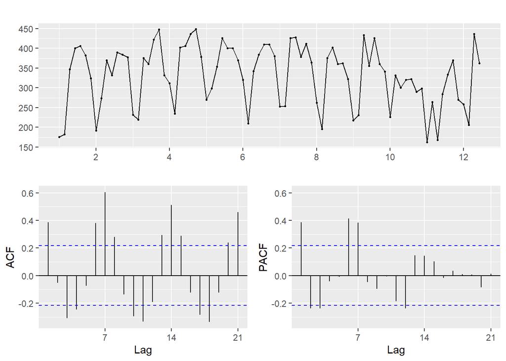

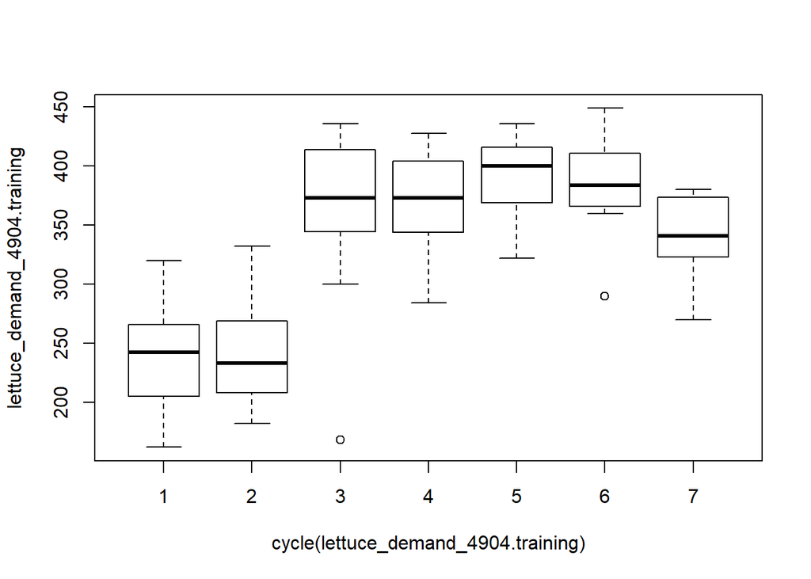

Therefore, ADF, PP and KPSS tests are used to formally test the stationarity of time series. The p-value from the PP tests are smaller than 0.05, and the p-value from KPSS tests is larger than 0.05. Therefore, based on all three tests, the non-seasonal part of the training dataset is most likely to be stationary.

Tests for the non-seasonal part of training dataset

| Test | P.Value |
| --- | --- |
| ADF | 0.0100000 |
| PP | 0.0100000 |
| KPSS | 0.0751784 |

Second, we could use ndiffs to verify the stationarity of the non-seasonal part of the training dataset, and use nsdiffs to determine the stationarity of the seasonal part. The results verify the analysis above that the non-seasonal part of the training dataset is stationary, and the seasonal part requires a first level differencing.

Differencing for the non-seasonal and seasonal part of training dataset

| Test | P.Value |
| --- | --- |
| ndiffs | 0 |
| nsdiffs | 1 |

We could verify the analysis above by taking a first level seasonal differencing and replot the dataset or re-run nsdiffs test. From the plots below, we could see that the seasonal pattern no longer exists, and the dataset is now stationary.

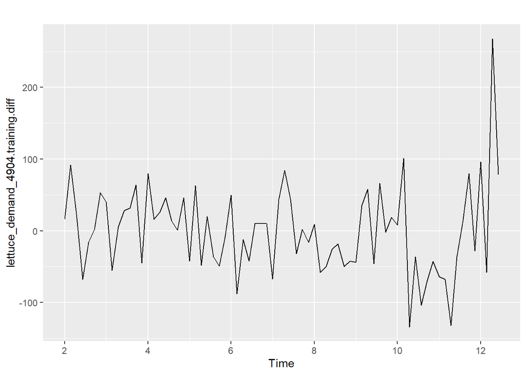

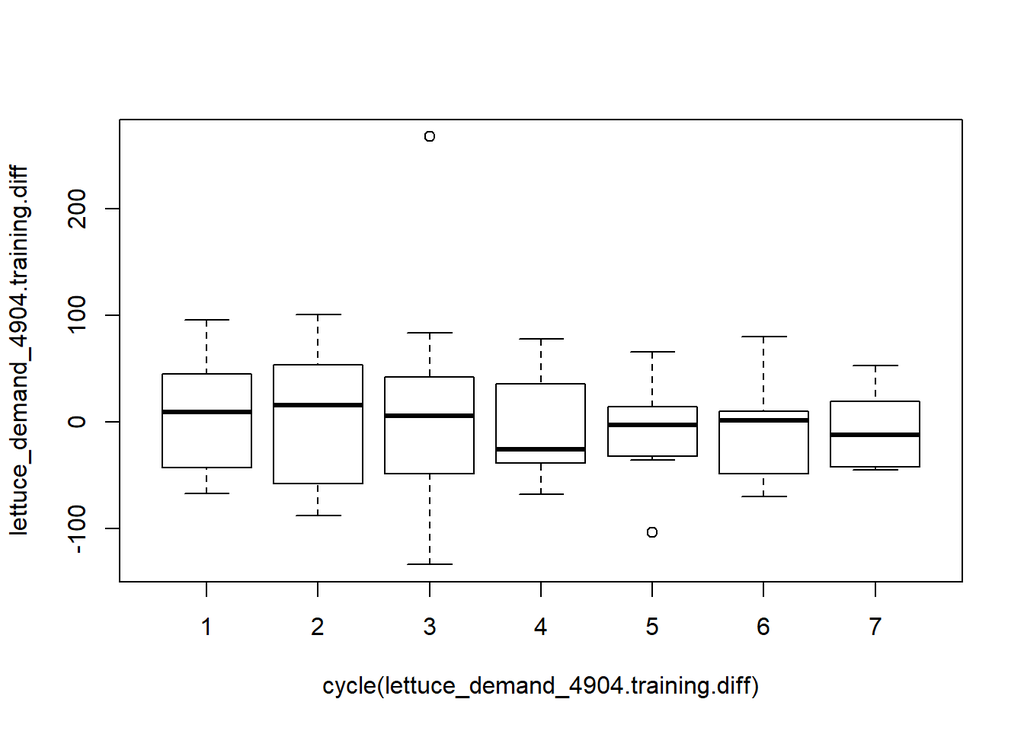

##### Section 2.1.2: Searching For The Best ARIMA Models

The Best Three ARIMA Models for Store 4904

| Ranks | Models | BIC |
| --- | --- | --- |
| Best Model | ARIMA(0,0,0)(2,1,0)[7] | 814.8431 |
| Second Best Model | ARIMA(1,0,1)(2,1,0)[7] | 815.9494 |
| Third Best Model | ARIMA(0,0,0)(1,1,0)[7] | 816.4742 |

##### Section 2.1.3: Calculating the Accuracy of the Best ARIMA Models

Accuracy of The Three Best ARIMA Models

|  | ME | RMSE | MAE | MPE | MAPE | MASE | ACF1 | Theil’s U |
| --- | --- | --- | --- | --- | --- | --- | --- | --- |
| M1 Training Dataset | -2.7652168 | 51.08438 | 38.18109 | -2.759800 | 12.952629 | 0.8107318 | 0.1189138 | NA |
| M1 Testing Dataset | 3.9936320 | 35.73311 | 30.16142 | -0.032410 | 9.986075 | 0.6404433 | -0.3477396 | 0.4763777 |
| M2 Training Dataset | -0.5390384 | 48.12504 | 35.12393 | -1.657746 | 11.855281 | 0.7458167 | -0.1212624 | NA |
| M2 Testing Dataset | -2.8671277 | 41.37553 | 33.59529 | -2.535405 | 11.375701 | 0.7133577 | -0.3400886 | 0.5575332 |
| M3 Training Dataset | -2.2953148 | 53.69751 | 38.56572 | -2.659931 | 12.887749 | 0.8188990 | 0.0378187 | NA |
| M3 Testing Dataset | 8.1226293 | 38.35442 | 28.00265 | 1.675166 | 8.569225 | 0.5946043 | -0.0648089 | 0.4693384 |

##### Section 2.1.4: Checking the Residuals of the Best ARIMA Model

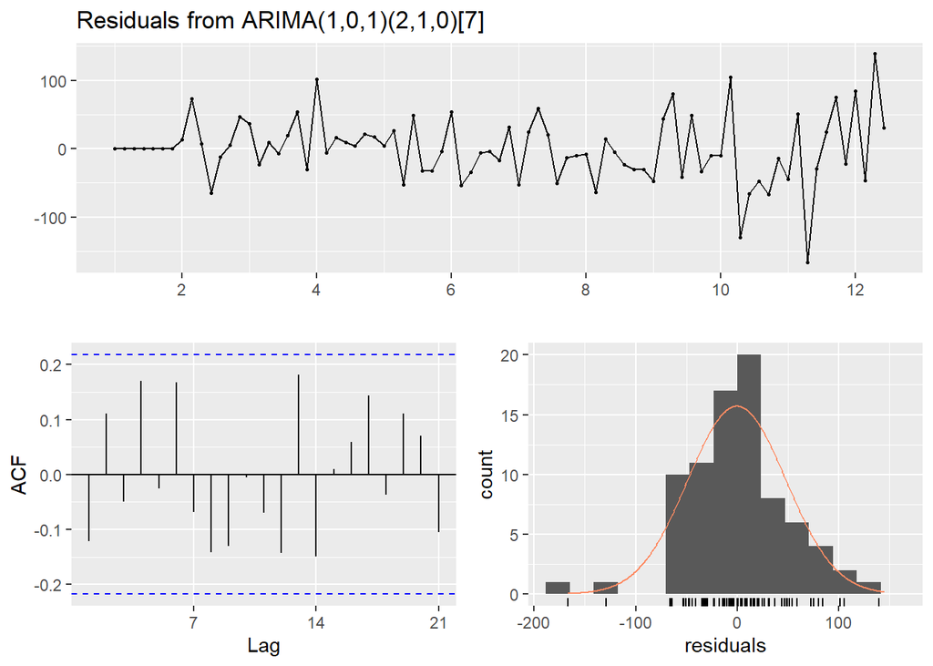

```
##
##  Ljung-Box test
##
## data:  Residuals from ARIMA(1,0,1)(2,1,0)[7]
## Q* = 19.433, df = 10, p-value = 0.0351
##
## Model df: 4.   Total lags used: 14
```

```r
checkresiduals(lettuce_demand_4904.training.m2)
```

#### Secton 2.2 : Applying the Holt-Winters Model

##### Section 2.2.1 Decompose the Training Dataset and Select the Model

By decomposing the original time series into trend, seasonal factors, and random error terms, we could see the relative importance of different components that are indicated by the grey bars in the plots. The grey bar for trend is long, while the grey bar for seasonal is short. Therefore, the decomposed plots suggest a ETS(A,N,A) model for Holt-Winters

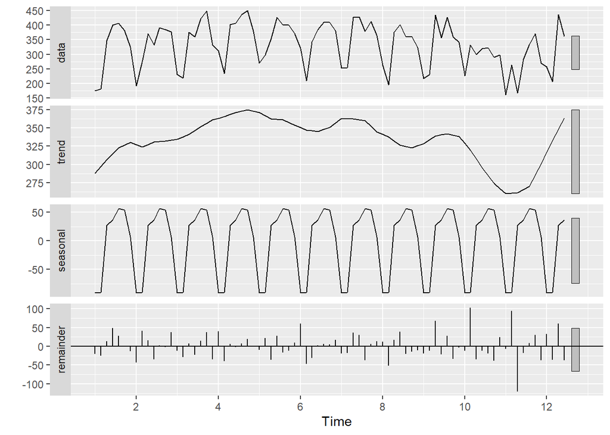

##### Section 2.2.2 Use ets to Select the Best Model

While using ets(), the best model for Holt-Winters is ETS(A,N,A), which matchs the analysi above.

```
## ETS(A,N,A)
##
## Call:
##  ets(y = lettuce_demand_4904.training, model = "ZZZ")
##
##   Smoothing parameters:
##     alpha = 0.194
##     gamma = 1e-04
##
##   Initial states:
##     l = 329.2286
##     s = 6.3379 52.1586 56.1676 42.0506 29.5549 -91.1832
##            -95.0864
##
##   sigma:  45.6581
##
##       AIC      AICc       BIC
##  985.4413  988.5842 1009.3858
```

##### Section 2.2.3 Calculating the Accuracy of the Best Holt-Winters Model

Calculate the out-of-sample performance based on multi-step ahead forecast

Accuracy of The Best Holt-Winters Model

|  | ME | RMSE | MAE | MPE | MAPE | MASE | ACF1 | Theil’s U |
| --- | --- | --- | --- | --- | --- | --- | --- | --- |
| ETS1 Training Dataset | -0.9194867 | 43.04688 | 32.02198 | -2.351651 | 10.999318 | 0.6799502 | -0.0667622 | NA |
| ETS2 Testing Dataset | -9.7799936 | 37.75467 | 28.39140 | -3.682129 | 9.266691 | 0.6028589 | 0.1306179 | 0.4259769 |

#### Secton 2.3: Final Forcast

##### Section 2.3.1: Comparing the forcast based on ARIMA and Holt-Winters Model

Comparing the result of ARIMA and Holt Winters Model

| Days | ARIMA | Holt.Winters |
| --- | --- | --- |
| 1 | 363.0797 | 370.9474 |
| 2 | 349.4694 | 366.9414 |
| 3 | 300.4023 | 321.1197 |
| 4 | 226.4843 | 219.6958 |
| 5 | 261.7287 | 223.5961 |
| 6 | 331.9676 | 344.3326 |
| 7 | 330.8903 | 356.8269 |
| 8 | 342.7378 | 370.9474 |
| 9 | 333.4010 | 366.9414 |
| 10 | 293.0809 | 321.1197 |
| 11 | 211.0379 | 219.6958 |
| 12 | 250.6041 | 223.5961 |
| 13 | 297.7963 | 344.3326 |
| 14 | 321.4086 | 356.8269 |

##### Section 2.3.2: Selecting Better Model from ARIMA and Holt-Winters Model

Accuracy of Best ARIMA and Holt-Winter Models

|  | ME | RMSE | MAE | MPE | MAPE | MASE | ACF1 | Theil’s U |
| --- | --- | --- | --- | --- | --- | --- | --- | --- |
| M2 Training Dataset | -0.5390384 | 48.12504 | 35.12393 | -1.657746 | 11.855281 | 0.7458167 | -0.1212624 | NA |
| M2 Testing Dataset | -2.8671277 | 41.37553 | 33.59529 | -2.535405 | 11.375701 | 0.7133577 | -0.3400886 | 0.5575332 |
| ets1 Training Dataset | -0.9194867 | 43.04688 | 32.02198 | -2.351651 | 10.999318 | 0.6799502 | -0.0667622 | NA |
| ets2 Testing Dataset | -9.7799936 | 37.75467 | 28.39140 | -3.682129 | 9.266691 | 0.6028589 | 0.1306179 | 0.4259769 |

##### Section 2.3.3: Generate the Final Forcast Using the Best Model

2 Week Prediction for Store 4904

|  | Point Forecast | Lo 80 | Hi 80 | Lo 95 | Hi 95 |
| --- | --- | --- | --- | --- | --- |
| 12.57143 | 370.9474 | 312.4342 | 429.4606 | 281.4592 | 460.4357 |
| 12.71429 | 366.9414 | 307.3374 | 426.5453 | 275.7850 | 458.0978 |
| 12.85714 | 321.1197 | 260.4446 | 381.7948 | 228.3251 | 413.9142 |
| 13.00000 | 219.6958 | 157.9682 | 281.4235 | 125.2915 | 314.1001 |
| 13.14286 | 223.5961 | 160.8336 | 286.3587 | 127.6091 | 319.5832 |
| 13.28571 | 344.3326 | 280.5520 | 408.1133 | 246.7885 | 441.8767 |
| 13.42857 | 356.8269 | 292.0431 | 421.6107 | 257.7486 | 455.9051 |
| 13.57143 | 370.9474 | 305.1768 | 436.7180 | 270.3599 | 471.5349 |
| 13.71429 | 366.9414 | 300.1985 | 433.6842 | 264.8670 | 469.0158 |
| 13.85714 | 321.1197 | 253.4185 | 388.8208 | 217.5797 | 424.6596 |
| 14.00000 | 219.6958 | 151.0498 | 288.3419 | 114.7108 | 324.6809 |
| 14.14286 | 223.5961 | 154.0180 | 293.1743 | 117.1856 | 330.0067 |
| 14.28571 | 344.3326 | 273.8348 | 414.8305 | 236.5155 | 452.1498 |
| 14.42857 | 356.8269 | 285.4202 | 428.2336 | 247.6197 | 466.0340 |

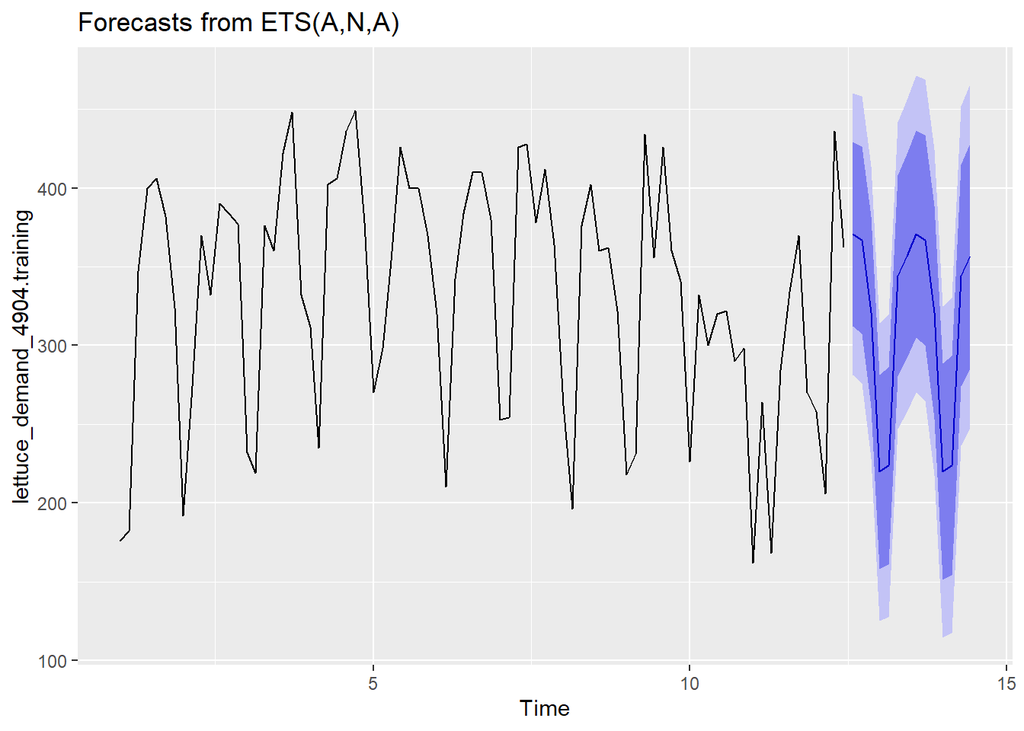

### Section 3: Forcasting The Demand of Store 12631

#### Secton 3.1: Applying the ARIMA Model

```
## Time Series:
## Start = c(1, 1)
## End = c(15, 5)
## Frequency = 7
##   [1] 232 227 181 221 229 237 235 244 218 205 248 153 222 262 259 274 250 209
##  [19] 202 207 251 256 246 251 214 218 245 268 236 352 190 280 232 243 217 309
##  [37] 354 212 264 252 251 306 291 328 221 199 249 241 265 279 313 233 324 354
##  [55] 324 307 316 324 203 369 246 267 256 313 277 257 264 238 259 361 316 263
##  [73] 233 256 220 258 237 350 271 194 244 289 253 318 371 351 279 236 204 252
##  [91] 241 279 232 245 282 230 294 235 376 366 229 234 232
```

##### Section 3.1.1: Verifying the Stationarity of the Training Set of Dataset.

For this dataset, we still need to verify the stationarity, while it shows similar patterns as the data of store 4904

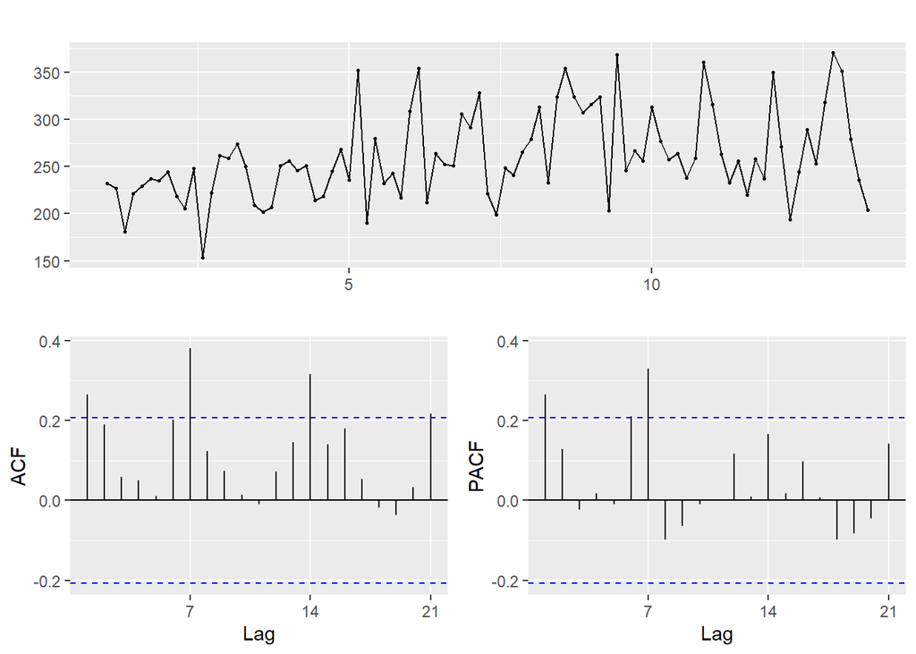

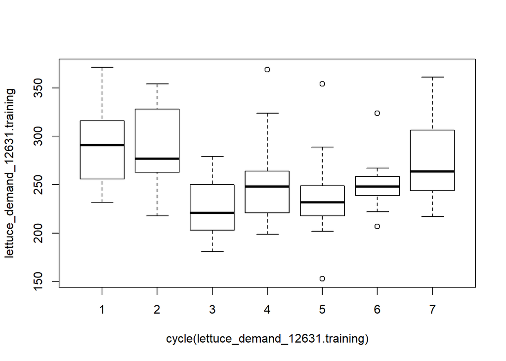

To simplify the analysis, for store 12631, we could use ndiffs and nsdiffs to directly determine the level of differences. The results is different from the data of store 4904. For store 12631, that the seasonal part of the training dataset is stationary, and the non-seasonal part requires a first level differencing.

Differencing for the non-seasonal and seasonal part of training dataset

| Test | P.Value |
| --- | --- |
| ndiffs | 1 |
| nsdiffs | 0 |

##### Section 3.1.2: Searching For The Best ARIMA Models

| Ranks | Models | BIC |
| --- | --- | --- |
| Best Model | ARIMA(0,1,1)(2,0,0)[7] | 922.2888 |
| Second Best Model | ARIMA(0,1,1)(1,0,0)[7] | 922.9761 |

##### Section 3.1.3: Calculating the Accuracy of the Best ARIMA Models

Calculate the out-of-sample performance of the best ARIMA models based on multi-step ahead forecast. Based on the accuracy of testing dataset, M1 and M3 have the best performance, while the performance of M3 is slightly better than M1. Therefore, we consider ARIMA(0,1,1)(2,1,0)[7] as the best ARIMA model.

Accuracy of The Three Best ARIMA Models

|  | ME | RMSE | MAE | MPE | MAPE | MASE | ACF1 | Theil’s U |
| --- | --- | --- | --- | --- | --- | --- | --- | --- |
| M1 Training Dataset | 4.103944 | 40.24048 | 31.06843 | -0.5328407 | 11.90586 | 0.8402411 | 0.0576681 | NA |
| M1 Testing Dataset | -12.488880 | 41.26388 | 37.45403 | -6.8059927 | 14.08000 | 1.0129389 | 0.0094552 | 0.6520634 |
| M2 Training Dataset | 5.000866 | 41.67053 | 31.99411 | -0.3315559 | 12.19249 | 0.8652760 | 0.0758991 | NA |
| M2 Testing Dataset | -13.678146 | 48.20897 | 42.93832 | -7.7253385 | 16.03808 | 1.1612606 | 0.1589265 | 0.7741603 |
| M3 Training Dataset | -2.229501 | 40.43221 | 31.07187 | -2.6063399 | 11.95891 | 0.8403343 | 0.0641527 | NA |
| M3 Testing Dataset | -13.064047 | 41.14443 | 33.13373 | -6.3204500 | 12.62034 | 0.8960968 | 0.2012796 | 0.6722532 |

#### Secton 3.2 : Applying the Holt-Winters Model

##### Section 3.2.1 Use ets to Select the Best Model

To simplifying the analysis, we sill use ets() to determine the best model for Holt-Winters. For store 12631, the best Holt-Winters to predict the demand is ETS(M,Ad,M).

```
## ETS(M,Ad,M)
##
## Call:
##  ets(y = lettuce_demand_12631.training, model = "ZZZ")
##
##   Smoothing parameters:
##     alpha = 1e-04
##     beta  = 1e-04
##     gamma = 1e-04
##     phi   = 0.9753
##
##   Initial states:
##     l = 214.8392
##     b = 1.968
##     s = 1.0449 0.9662 0.9145 0.9813 0.853 1.1398
##            1.1003
##
##   sigma:  0.1389
##
##      AIC     AICc      BIC
## 1050.788 1055.641 1083.140
```

##### Section 3.2.2 Calculating the Accuracy of the Best Holt-Winters Model

Calculate the out-of-sample performance based on multi-step ahead forecast

Accuracy of The Best Holt-Winters Model

|  | ME | RMSE | MAE | MPE | MAPE | MASE | ACF1 | Theil’s U |
| --- | --- | --- | --- | --- | --- | --- | --- | --- |
| ETS1 Training Dataset | -1.077097 | 34.11242 | 26.09866 | -2.108286 | 10.08561 | 0.7058346 | 0.0615298 | NA |
| ETS2 Testing Dataset | -19.235015 | 44.30622 | 36.85583 | -9.276175 | 14.25979 | 0.9967607 | -0.0016113 | 0.7245148 |

#### Secton 3.3: Final Forcast

##### Section 3.3.1: Comparing the forcast based on ARIMA and Holt-Winters Model

Comparing the result of ARIMA and Holt Winters Model

| Days | ARIMA | Holt.Winters |
| --- | --- | --- |
| 1 | 259.5028 | 274.6589 |
| 2 | 303.9090 | 297.2379 |
| 3 | 351.9647 | 313.2411 |
| 4 | 302.2169 | 324.6814 |
| 5 | 239.6804 | 243.1538 |
| 6 | 247.3119 | 279.8874 |
| 7 | 241.5432 | 261.0075 |
| 8 | 259.9199 | 275.9276 |
| 9 | 294.1297 | 298.5760 |
| 10 | 361.3131 | 314.6155 |
| 11 | 314.2869 | 326.0700 |
| 12 | 244.5256 | 244.1674 |
| 13 | 245.5399 | 281.0245 |
| 14 | 244.0527 | 262.0411 |

##### Section 3.3.2: Selecting Better Model from ARIMA and Holt-Winters Model

The table below compares the performance of the best ARIMA and Holt-Winters models. It appears that ARIMA model has a better performance than Holt-Winters model. Therefore, we consider ARIMA(0,1,1)(2,1,0)[7] as the best model

Accuracy of Best ARIMA and Holt-Winter Models

|  | ME | RMSE | MAE | MPE | MAPE | MASE | ACF1 | Theil’s U |
| --- | --- | --- | --- | --- | --- | --- | --- | --- |
| M3 Training Dataset | -2.229501 | 40.43221 | 31.07187 | -2.606340 | 11.95891 | 0.8403343 | 0.0641527 | NA |
| M3 Testing Dataset | -13.064047 | 41.14443 | 33.13373 | -6.320450 | 12.62034 | 0.8960968 | 0.2012796 | 0.6722532 |
| ets1 Training Dataset | -1.077097 | 34.11242 | 26.09866 | -2.108286 | 10.08561 | 0.7058346 | 0.0615298 | NA |
| ets2 Testing Dataset | -19.235015 | 44.30622 | 36.85583 | -9.276175 | 14.25979 | 0.9967607 | -0.0016113 | 0.7245148 |

##### Section 3.3.3: Generate the Final Forcast Using the Best Model

2 Week Prediction for Store 12631

|  | Point Forecast | Lo 80 | Hi 80 | Lo 95 | Hi 95 |
| --- | --- | --- | --- | --- | --- |
| 13.71429 | 259.5028 | 204.1533 | 314.8523 | 174.8531 | 344.1525 |
| 13.85714 | 303.9090 | 248.4545 | 359.3634 | 219.0988 | 388.7191 |
| 14.00000 | 351.9647 | 296.4056 | 407.5238 | 266.9944 | 436.9351 |
| 14.14286 | 302.2169 | 246.5533 | 357.8806 | 217.0867 | 387.3471 |
| 14.28571 | 239.6804 | 183.9124 | 295.4484 | 154.3907 | 324.9702 |
| 14.42857 | 247.3119 | 191.4398 | 303.1840 | 161.8629 | 332.7609 |
| 14.57143 | 241.5432 | 185.5672 | 297.5192 | 155.9353 | 327.1512 |
| 14.71429 | 259.9199 | 198.8862 | 320.9536 | 166.5769 | 353.2629 |
| 14.85714 | 294.1297 | 232.9154 | 355.3439 | 200.5106 | 387.7488 |
| 15.00000 | 361.3131 | 299.9188 | 422.7074 | 267.4187 | 455.2075 |
| 15.14286 | 314.2869 | 252.7132 | 375.8607 | 220.1180 | 408.4559 |
| 15.28571 | 244.5256 | 182.7728 | 306.2783 | 150.0829 | 338.9682 |
| 15.42857 | 245.5399 | 183.6087 | 307.4710 | 150.8243 | 340.2554 |
| 15.57143 | 244.0527 | 181.9436 | 306.1618 | 149.0650 | 339.0404 |

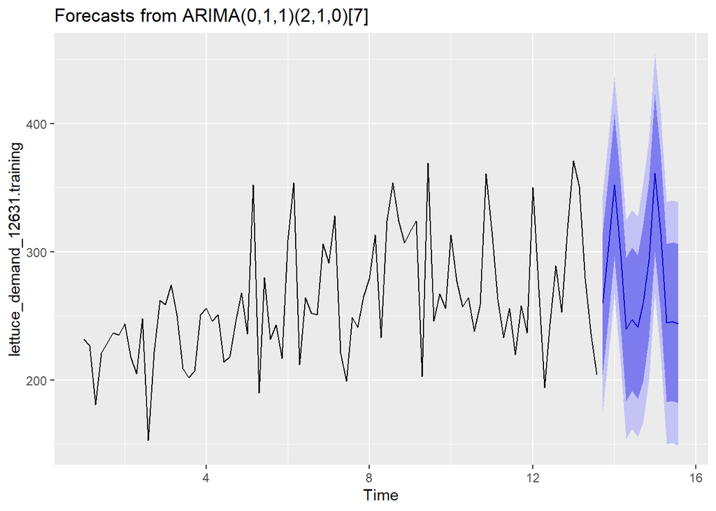

### Section 4: Forcasting The Demand of Store 20974

#### Secton 4.1: Applying the ARIMA Model

```
## Time Series:
## Start = c(11, 5)
## End = c(13, 4)
## Frequency = 7
##  [1] 228 249 219 185 161 200 224 210 256 386 170 206 167 266
```

##### Section 4.1.1: Verifying the Stationarity of the Training Set of Dataset.

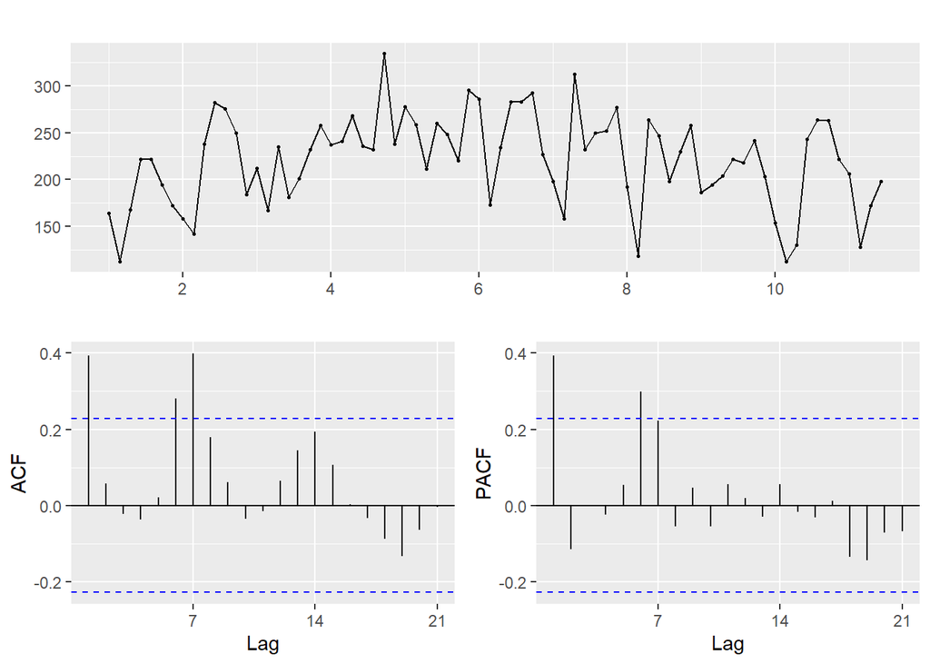

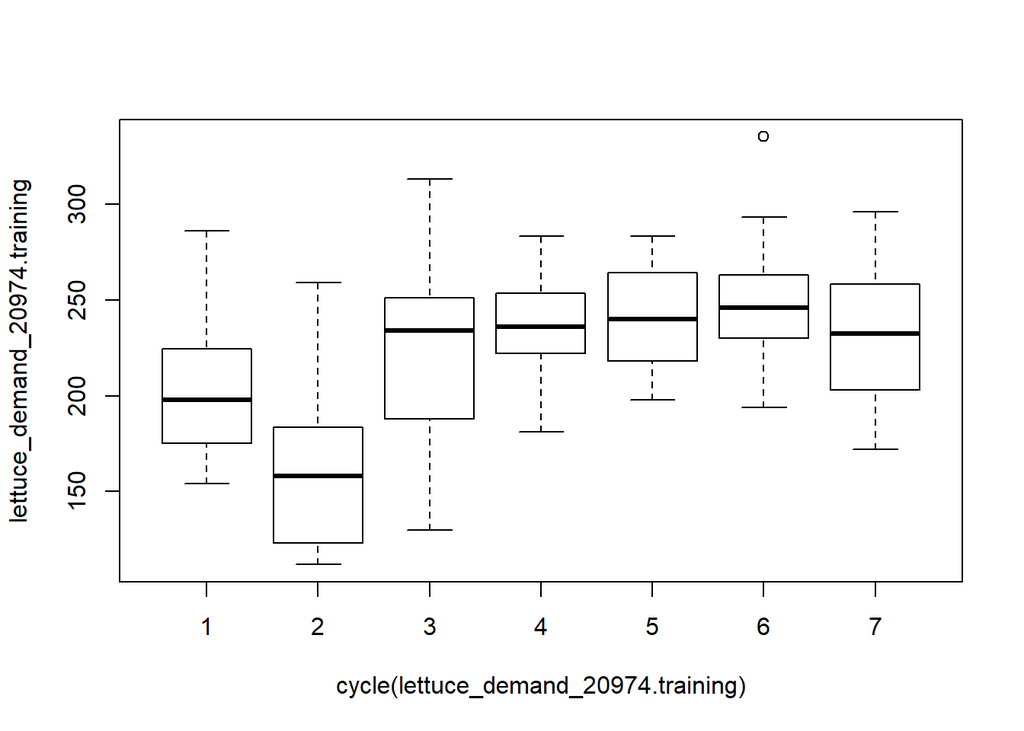

To simplify the analysis, for store 20974, we could use ndiffs and nsdiffs to directly determine the level of differences. For store 20974, that the seasonal part of the training dataset is stationary, and the non-seasonal part is also stationary.

Differencing for the non-seasonal and seasonal part of training dataset

| Test | P.Value |
| --- | --- |
| ndiffs | 0 |
| nsdiffs | 0 |

##### Section 4.1.2: Searching For The Best ARIMA Models

We could use auto.arima() to search for the best ARIMA models. The three best models that the corresponding BICs are shown below. While the BIC of best model is 778.9095, there are some other models that return the comparable BICs as the best model. Therefore, we chose two models that have the lowest BIC. Moreover, since we detect the seasonality from the boxplot, we could add another ARIMA model with D = 1.

| Ranks | Models | BIC |
| --- | --- | --- |
| Best Model | ARIMA(0,0,1)(1,0,0)[7] | 778.9095 |
| Second Best Model | ARIMA(1,0,0)(1,0,0)[7] | 779.0975 |

##### Section 4.1.3: Calculating the Accuracy of the Best ARIMA Models

Calculate the out-of-sample performance of the best ARIMA models based on multi-step ahead forecast. Based on the accuracy of testing dataset, M1 and M2 have the best performance, while the performance of M1 is slightly better than M2. Therefore, we consider ARIMA(0,0,1)(1,0,0)[7] with non-zero mean as the best ARIMA model.

Accuracy of The Three Best ARIMA Models

|  | ME | RMSE | MAE | MPE | MAPE | MASE | ACF1 | Theil’s U |
| --- | --- | --- | --- | --- | --- | --- | --- | --- |
| M1 Training Dataset | 1.311949 | 41.25520 | 34.43139 | -3.6198220 | 17.05045 | 0.7985126 | 0.0116638 | NA |
| M1 Testing Dataset | 9.050477 | 51.84876 | 31.13722 | -0.0923182 | 12.69418 | 0.7221162 | -0.1438066 | 0.7374804 |
| M2 Training Dataset | 1.345138 | 41.30998 | 34.58846 | -3.5862734 | 17.08742 | 0.8021553 | 0.0162145 | NA |
| M2 Testing Dataset | 9.599847 | 52.07030 | 31.41663 | 0.1429625 | 12.78273 | 0.7285961 | -0.1410254 | 0.7410885 |
| M3 Training Dataset | 2.048846 | 43.45896 | 33.36262 | -1.5746474 | 15.74792 | 0.7737264 | -0.0021569 | NA |
| M3 Testing Dataset | 23.574023 | 56.06554 | 34.81790 | 8.6260060 | 14.23557 | 0.8074764 | -0.3024375 | 0.8865019 |

#### Secton 4.2 : Applying the Holt-Winters Model

##### Section 4.2.1 Use ets to Select the Best Model

To simplifying the analysis, we sill use ets() to determine the best model for Holt-Winters. For store 20974, the best Holt-Winters to predict the demand is ETS(A,N,A).

```
## ETS(A,N,A)
##
## Call:
##  ets(y = lettuce_demand_20974.training, model = "ZZZ")
##
##   Smoothing parameters:
##     alpha = 0.1917
##     gamma = 1e-04
##
##   Initial states:
##     l = 207.7893
##     s = 11.6506 30.1553 11.4656 16.7334 -1.1621 -54.6163
##            -14.2265
##
##   sigma:  39.4136
##
##      AIC     AICc      BIC
## 872.6729 876.1650 895.7135
```

##### Section 4.2.2 Calculating the Accuracy of the Best Holt-Winters Model

Calculate the out-of-sample performance based on multi-step ahead forecast

Accuracy of The Best Holt-Winters Model

|  | ME | RMSE | MAE | MPE | MAPE | MASE | ACF1 | Theil’s U |
| --- | --- | --- | --- | --- | --- | --- | --- | --- |
| ETS1 Training Dataset | -0.8288387 | 36.93911 | 31.56763 | -3.327111 | 15.14569 | 0.7320981 | 0.1633262 | NA |
| ETS2 Testing Dataset | 27.3275649 | 54.92291 | 32.99506 | 9.398126 | 12.77402 | 0.7652022 | -0.2811798 | 0.8183976 |

#### Secton 4.3: Final Forcast

##### Section 4.3.1: Comparing the forcast based on ARIMA and Holt-Winters Model

Comparing the result of ARIMA and Holt Winters Model

| Days | ARIMA | Holt.Winters |
| --- | --- | --- |
| 1 | 225.0568 | 207.5001 |
| 2 | 234.7654 | 226.1822 |
| 3 | 219.4653 | 207.6791 |
| 4 | 213.4945 | 181.8025 |
| 5 | 184.3870 | 141.4107 |
| 6 | 200.8066 | 194.8700 |
| 7 | 210.5091 | 212.7624 |
| 8 | 220.6060 | 207.5001 |
| 9 | 224.2290 | 226.1822 |
| 10 | 218.5194 | 207.6791 |
| 11 | 216.2913 | 181.8025 |
| 12 | 205.4291 | 141.4107 |
| 13 | 211.5565 | 194.8700 |
| 14 | 215.1772 | 212.7624 |

##### Section 4.3.2: Selecting Better Model from ARIMA and Holt-Winters Model

Accuracy of Best ARIMA and Holt-Winter Models

|  | ME | RMSE | MAE | MPE | MAPE | MASE | ACF1 | Theil’s U |
| --- | --- | --- | --- | --- | --- | --- | --- | --- |
| M1 Training Dataset | 1.3119490 | 41.25520 | 34.43139 | -3.6198220 | 17.05045 | 0.7985126 | 0.0116638 | NA |
| M1 Testing Dataset | 9.0504774 | 51.84876 | 31.13722 | -0.0923182 | 12.69418 | 0.7221162 | -0.1438066 | 0.7374804 |
| ets1 Training Dataset | -0.8288387 | 36.93911 | 31.56763 | -3.3271108 | 15.14569 | 0.7320981 | 0.1633262 | NA |
| ets2 Testing Dataset | 27.3275649 | 54.92291 | 32.99506 | 9.3981256 | 12.77402 | 0.7652022 | -0.2811798 | 0.8183976 |

##### Section 4.3.3: Generate the Final Forcast Using the Best Model

2 Week Prediction for Store 20974

|  | Point Forecast | Lo 80 | Hi 80 | Lo 95 | Hi 95 |
| --- | --- | --- | --- | --- | --- |
| 11.57143 | 225.0568 | 171.0807 | 279.0329 | 142.50749 | 307.6061 |
| 11.71429 | 234.7654 | 177.9724 | 291.5585 | 147.90792 | 321.6229 |
| 11.85714 | 219.4653 | 162.6722 | 276.2584 | 132.60780 | 306.3228 |
| 12.00000 | 213.4945 | 156.7015 | 270.2876 | 126.63702 | 300.3520 |
| 12.14286 | 184.3870 | 127.5939 | 241.1800 | 97.52948 | 271.2445 |
| 12.28571 | 200.8066 | 144.0136 | 257.5997 | 113.94912 | 287.6641 |
| 12.42857 | 210.5091 | 153.7161 | 267.3022 | 123.65163 | 297.3666 |
| 12.57143 | 220.6060 | 160.3468 | 280.8652 | 128.44753 | 312.7645 |
| 12.71429 | 224.2290 | 163.6103 | 284.8477 | 131.52075 | 316.9373 |
| 12.85714 | 218.5194 | 157.9007 | 279.1381 | 125.81115 | 311.2277 |
| 13.00000 | 216.2913 | 155.6726 | 276.9100 | 123.58301 | 308.9995 |
| 13.14286 | 205.4291 | 144.8104 | 266.0478 | 112.72084 | 298.1374 |
| 13.28571 | 211.5565 | 150.9378 | 272.1752 | 118.84822 | 304.2648 |
| 13.42857 | 215.1772 | 154.5585 | 275.7959 | 122.46894 | 307.8855 |

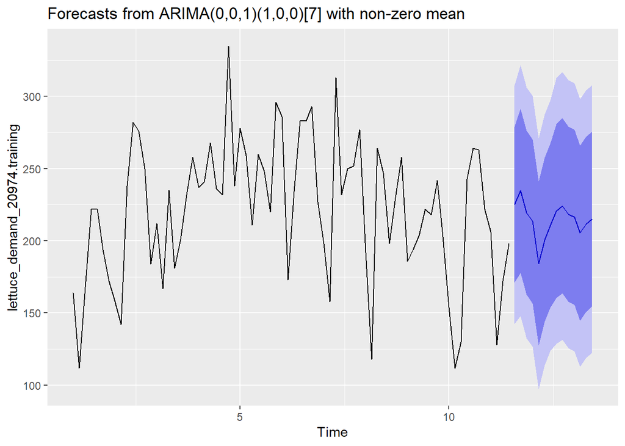

### Section 5: Forcasting The Demand of Store 46673

#### Secton 5.1: Applying the ARIMA Model

##### Section 5.1.1: Verifying the Stationarity of the Training Set of Dataset.

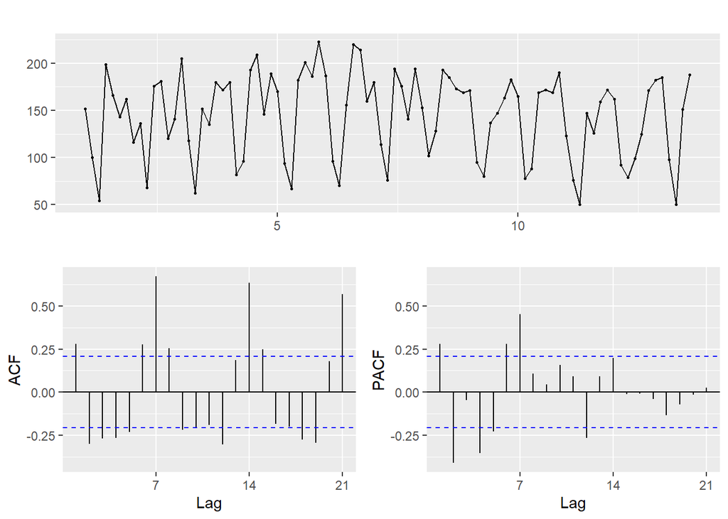

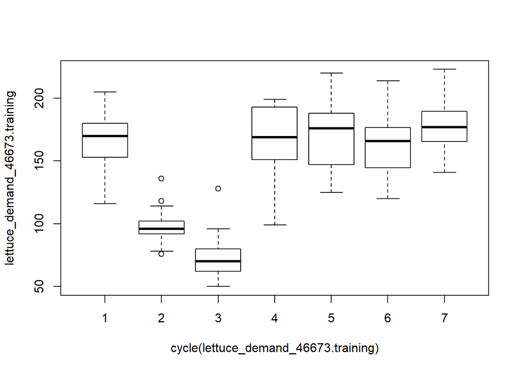

Differencing for the non-seasonal and seasonal part of training dataset

| Test | P.Value |
| --- | --- |
| ndiffs | 0 |
| nsdiffs | 1 |

##### Section 5.1.2: Searching For The Best ARIMA Models

We could use auto.arima() to search for the best ARIMA models. The three best models that the corresponding BICs are shown below. While the BIC of best model is 781.1482, there are some other models that return the comparable BICs as the best model. Therefore, we chose three models that have the lowest BIC.

```
##
##  ARIMA(2,0,2)(1,1,1)[7] with drift         : Inf
##  ARIMA(0,0,0)(0,1,0)[7] with drift         : 812.3871
##  ARIMA(1,0,0)(1,1,0)[7] with drift         : 797.7016
##  ARIMA(0,0,1)(0,1,1)[7] with drift         : 786.6812
##  ARIMA(0,0,0)(0,1,0)[7]                    : 808.0081
##  ARIMA(0,0,1)(0,1,0)[7] with drift         : 816.6708
##  ARIMA(0,0,1)(1,1,1)[7] with drift         : 791.0856
##  ARIMA(0,0,1)(0,1,2)[7] with drift         : 791.0858
##  ARIMA(0,0,1)(1,1,0)[7] with drift         : 797.5401
##  ARIMA(0,0,1)(1,1,2)[7] with drift         : Inf
##  ARIMA(0,0,0)(0,1,1)[7] with drift         : 785.0149
##  ARIMA(0,0,0)(1,1,1)[7] with drift         : 789.0588
##  ARIMA(0,0,0)(0,1,2)[7] with drift         : 789.1369
##  ARIMA(0,0,0)(1,1,0)[7] with drift         : 794.4818
##  ARIMA(0,0,0)(1,1,2)[7] with drift         : Inf
##  ARIMA(1,0,0)(0,1,1)[7] with drift         : 786.8519
##  ARIMA(1,0,1)(0,1,1)[7] with drift         : 791.0616
##  ARIMA(0,0,0)(0,1,1)[7]                    : 781.1482
##  ARIMA(0,0,0)(1,1,1)[7]                    : 785.3788
##  ARIMA(0,0,0)(0,1,2)[7]                    : 785.4227
##  ARIMA(0,0,0)(1,1,0)[7]                    : 790.0845
##  ARIMA(0,0,0)(1,1,2)[7]                    : 789.9197
##  ARIMA(1,0,0)(0,1,1)[7]                    : 782.8503
##  ARIMA(0,0,1)(0,1,1)[7]                    : 782.7104
##  ARIMA(1,0,1)(0,1,1)[7]                    : 787.1072
##
##  Best model: ARIMA(0,0,0)(0,1,1)[7]
```

```
## Series: lettuce_demand_46673.training
## ARIMA(0,0,0)(0,1,1)[7]
##
## Coefficients:
##          sma1
##       -0.7476
## s.e.   0.1199
##
## sigma^2 estimated as 680.8:  log likelihood=-386.17
## AIC=776.33   AICc=776.49   BIC=781.15
```

The Best Three ARIMA Models for Store 46673

| Ranks | Models | BIC |
| --- | --- | --- |
| Best Model | ARIMA(0,0,0)(0,1,1)[7] | 781.1482 |
| Second Best Model | ARIMA(0,0,1)(0,1,1)[7] | 782.7104 |
| Third Best Model | ARIMA(1,0,0)(0,1,1)[7] | 782.8503 |

##### Section 5.1.3: Calculating the Accuracy of the Best ARIMA Models

Accuracy of The Three Best ARIMA Models

|  | ME | RMSE | MAE | MPE | MAPE | MASE | ACF1 | Theil’s U |
| --- | --- | --- | --- | --- | --- | --- | --- | --- |
| M1 Training Dataset | -0.0632055 | 24.89233 | 18.27833 | -2.935965 | 13.78152 | 0.6872184 | 0.1811863 | NA |
| M1 Testing Dataset | 8.6745680 | 41.49454 | 30.70063 | 3.132855 | 19.59288 | 1.1542648 | 0.1803610 | 0.6557006 |
| M2 Training Dataset | 0.0028287 | 24.33113 | 17.78837 | -2.705200 | 13.37245 | 0.6687969 | 0.0035688 | NA |
| M2 Testing Dataset | 7.4932548 | 41.08078 | 30.72942 | 2.313730 | 19.62275 | 1.1553471 | 0.1711167 | 0.6433336 |
| M3 Training Dataset | 0.0228809 | 24.34700 | 17.82533 | -2.726029 | 13.36990 | 0.6701867 | 0.0132016 | NA |
| M3 Testing Dataset | 7.3655972 | 41.09264 | 30.77366 | 2.230649 | 19.64924 | 1.1570106 | 0.1722622 | 0.6432981 |

#### Secton 5.2 : Applying the Holt-Winters Model

##### Section 5.2.1 Use ets to Select the Best Model

To simplifying the analysis, we sill use ets() to determine the best model for Holt-Winters. For store 46673, the best Holt-Winters to predict the demand is ETS(A,N,A).

```
## ETS(A,N,A)
##
## Call:
##  ets(y = lettuce_demand_46673.training, model = "ZZZ")
##
##   Smoothing parameters:
##     alpha = 0.0946
##     gamma = 1e-04
##
##   Initial states:
##     l = 146.0165
##     s = 32.6444 19.1329 25.5759 20.8428 -70.5411 -47.1212
##            19.4663
##
##   sigma:  24.3637
##
##       AIC      AICc       BIC
##  978.3710  981.1915 1003.2574
```

##### Section 5.2.2 Calculating the Accuracy of the Best Holt-Winters Model

Calculate the out-of-sample performance based on multi-step ahead forecast

Accuracy of The Best Holt-Winters Model

|  | ME | RMSE | MAE | MPE | MAPE | MASE | ACF1 | Theil’s U |
| --- | --- | --- | --- | --- | --- | --- | --- | --- |
| ETS1 Training Dataset | -1.014638 | 23.09898 | 18.47706 | -3.708049 | 14.26531 | 0.6946899 | 0.0879864 | NA |
| ETS2 Testing Dataset | 12.025567 | 38.53718 | 28.55525 | 5.920676 | 18.50333 | 1.0736040 | 0.0779578 | 0.608142 |

#### Secton 5.3: Final Forcast

##### Section 5.3.1: Comparing the forcast based on ARIMA and Holt-Winters Model

Comparing the result of ARIMA and Holt Winters Model

| Days | ARIMA | Holt.Winters |
| --- | --- | --- |
| 1 | 171.92078 | 156.60619 |
| 2 | 181.07456 | 170.11891 |
| 3 | 165.05864 | 156.94131 |
| 4 | 93.47459 | 90.35365 |
| 5 | 71.40276 | 66.93300 |
| 6 | 151.29190 | 158.31624 |
| 7 | 163.47659 | 163.05173 |
| 8 | 167.41630 | 156.60619 |
| 9 | 180.24717 | 170.11891 |
| 10 | 164.90666 | 156.94131 |
| 11 | 93.44667 | 90.35365 |
| 12 | 71.39764 | 66.93300 |
| 13 | 151.29096 | 158.31624 |
| 14 | 163.47641 | 163.05173 |

##### Section 5.3.2: Selecting Better Model from ARIMA and Holt-Winters Model

Accuracy of Best ARIMA and Holt-Winter Models

|  | ME | RMSE | MAE | MPE | MAPE | MASE | ACF1 | Theil’s U |
| --- | --- | --- | --- | --- | --- | --- | --- | --- |
| M3 Training Dataset | 0.0228809 | 24.34700 | 17.82533 | -2.726029 | 13.36990 | 0.6701867 | 0.0132016 | NA |
| M3 Testing Dataset | 7.3655972 | 41.09264 | 30.77366 | 2.230649 | 19.64924 | 1.1570106 | 0.1722622 | 0.6432981 |
| ets1 Training Dataset | -1.0146385 | 23.09898 | 18.47706 | -3.708049 | 14.26531 | 0.6946899 | 0.0879864 | NA |
| ets2 Testing Dataset | 12.0255674 | 38.53718 | 28.55525 | 5.920676 | 18.50333 | 1.0736040 | 0.0779578 | 0.6081420 |

##### Section 5.3.3: Generate the Final Forcast Using the Best Model

2 Week Prediction for Store 46673

|  | Point Forecast | Lo 80 | Hi 80 | Lo 95 | Hi 95 |
| --- | --- | --- | --- | --- | --- |
| 13.71429 | 171.92078 | 138.99277 | 204.8488 | 121.56173 | 222.2798 |
| 13.85714 | 181.07456 | 147.59591 | 214.5532 | 129.87338 | 232.2757 |
| 14.00000 | 165.05864 | 131.56833 | 198.5489 | 113.83963 | 216.2776 |
| 14.14286 | 93.47459 | 59.98366 | 126.9655 | 42.25464 | 144.6945 |
| 14.28571 | 71.40276 | 37.91182 | 104.8937 | 20.18278 | 122.6227 |
| 14.42857 | 151.29190 | 117.80096 | 184.7829 | 100.07192 | 202.5119 |
| 14.57143 | 163.47659 | 129.98564 | 196.9675 | 112.25660 | 214.6966 |
| 14.71429 | 167.41630 | 133.16210 | 201.6705 | 115.02903 | 219.8036 |
| 14.85714 | 180.24717 | 145.96775 | 214.5266 | 127.82132 | 232.6730 |
| 15.00000 | 164.90666 | 130.63300 | 199.1803 | 112.48962 | 217.3237 |
| 15.14286 | 93.44667 | 59.17298 | 127.7204 | 41.02958 | 145.8638 |
| 15.28571 | 71.39764 | 37.12394 | 105.6713 | 18.98055 | 123.8147 |
| 15.42857 | 151.29096 | 117.01727 | 185.5647 | 98.87387 | 203.7081 |
| 15.57143 | 163.47641 | 129.20272 | 197.7501 | 111.05933 | 215.8935 |

[figure not shown]